# Caret case studies

```r
library(readxl)
library(dplyr)
library(tidyr)
library(caret)

knitr::opts_chunk$set(echo = T,
                      warning = FALSE)
```

```r
# Set name of outcome of interest
outcome <- "Total"
# Options:
# "ArsonandCriminalDamage"
# "Burglary"
# "DrugOffences"
# "MiscellaneousCrimesAgainstSociety"
# "PossessionofWeapons"
# "PublicOrderOffences"
# "Robbery"
# "SexualOffences"
# "Theft"
# "VehicleOffences"
# "ViolenceAgainstthePerson"
# "Total"
```

# Feature engineering

First, we must load our data and make sure it’s in a shape where R and caret will know how to handle it.

We use open data from the Greater London Authority:

- Borough profiles: https://data.london.gov.uk/dataset/london-borough-profiles
- Borough crime statistics: https://data.london.gov.uk/dataset/recorded_crime_summary

Note that the profile predictors reflect data collected in many different years. Ideally, this would not be the case, especially since some of these variables may have fairly high variance over time!

```r
# Prepare Borough profiles
download.file("https://data.london.gov.uk/dataset/london-borough-profiles/resource/80647ce7-14f3-4e31-b1cd-d5f7ea3553be/download",
              "borough_profiles.xlsx")
borough_profiles <- readxl::read_excel("borough_profiles.xlsx",
                               sheet = "Data") %>%
  # Remove ID columns (except borough name)
  dplyr::select(-"Code", -"New code") %>%
  # Remove NA rows (incl. group-level rows)
  tidyr::drop_na() %>%
  # Replace all "." where the cell should be empty
  dplyr::mutate_if(is.character, list(~na_if(., "."))) %>%
  dplyr::mutate_if(is.character, list(~na_if(., "n/a")))
# Coerce everything to numeric
borough_profiles[,3:ncol(borough_profiles)] <- apply(borough_profiles[,3:ncol(borough_profiles)], 2, as.numeric)
# Remove columns that are now all-NA because of the numeric type
borough_profiles <- borough_profiles %>%
  dplyr::select_if(function (x) all(!is.na(x)))
```

We will only keep crime data from January 2018. If useful to you, there is information available on how to use caret for [time series data](https://topepo.github.io/caret/data-splitting.html#data-splitting-for-time-series) instead.

```r
# Prepare Borough crime stats
borough_crime <- read.csv("https://data.london.gov.uk/download/recorded_crime_summary/d2e9ccfc-a054-41e3-89fb-53c2bc3ed87a/MPS%20Borough%20Level%20Crime%20%28most%20recent%2024%20months%29.csv")

# Create summary of the crime information
borough_crime <- borough_crime %>%
  dplyr::group_by(LookUp_BoroughName, MajorText) %>%
  dplyr::summarize_if(is.numeric, sum, na.rm=TRUE) %>%
  # Only keep January 2018 data
  dplyr::select(LookUp_BoroughName, MajorText, X201801) %>%
  tidyr::spread(MajorText, X201801) %>%
  dplyr::ungroup() %>%
  dplyr::mutate(Total = rowSums(.[2:12]))
```

Once the crime statistics and the borough profiles are joined together, this is the final data we will use for modelling.

```r
borough_summ <- dplyr::right_join(borough_profiles, borough_crime,
                                  by = c("Area name" = "LookUp_BoroughName"))
(borough_summ)
```

| Area name | Inner/ Outer London | GLA Population Estimate 2017 | GLA Household Estimate 2017 | Inland Area (Hectares) | Population density (per hectare) 2017 | Average Age, 2017 | Proportion of population aged 0-15, 2015 | Proportion of population of working-age, 2015 | Proportion of population aged 65 and over, 2015 | Net internal migration (2015) | Net international migration (2015) | Net natural change (2015) | % of largest migrant population (2011) | % of second largest migrant population (2011) | % of third largest migrant population (2011) | % of population from BAME groups (2016) | % people aged 3+ whose main language is not English (2011 Census) | Overseas nationals entering the UK (NINo), (2015/16) | New migrant (NINo) rates, (2015/16) | Employment rate (%) (2015) | Youth Unemployment (claimant) rate 18-24 (Dec-15) | Proportion of the working-age population who claim out-of-work benefits (%) (May-2016) | Modelled Household median income estimates 2012/13 | Number of jobs by workplace (2014) | % of employment that is in public sector (2014) | Jobs Density, 2015 | Number of active businesses, 2015 | Two-year business survival rates (started in 2013) | Fires per thousand population (2014) | … |
| --- | --- | --- | --- | --- | --- | --- | --- | --- | --- | --- | --- | --- | --- | --- | --- | --- | --- | --- | --- | --- | --- | --- | --- | --- | --- | --- | --- | --- | --- | --- |
| Barking and Dagenham | Outer London | 209000 | 78188.38 | 3610.782 | 57.88220 | 32.9 | 27.2 | 63.1 | 9.7 | -1176 | 2509 | 2356 | 4.676969 | 2.3473598 | 2.3328367 | 49.53176 | 18.724201 | 7538 | 59.13966 | 65.8 | 4.496664 | 10.528711 | 29420 | 58900 | 21.10454 | 0.48 | 6560 | 73.0 | 3.030151 | … |
| Barnet | Outer London | 389600 | 151422.96 | 8674.831 | 44.91154 | 37.3 | 21.1 | 64.9 | 14.0 | -3379 | 5407 | 2757 | 3.061849 | 2.4170422 | 2.0320664 | 38.66373 | 23.405037 | 13094 | 53.11364 | 68.5 | 1.937492 | 6.202135 | 40530 | 167300 | 18.66667 | 0.67 | 26190 | 73.8 | 1.624000 | … |
| Bexley | Outer London | 244300 | 97735.84 | 6058.067 | 40.32640 | 39.0 | 20.6 | 62.9 | 16.6 | 413 | 760 | 1095 | 2.590982 | 1.4668293 | 0.9064772 | 21.40627 | 6.031289 | 2198 | 14.43356 | 75.1 | 2.853710 | 6.776812 | 36990 | 80700 | 15.87983 | 0.56 | 9075 | 73.5 | 2.269682 | … |
| Brent | Outer London | 332100 | 121048.27 | 4323.264 | 76.81697 | 35.6 | 20.9 | 67.8 | 11.3 | -7739 | 7640 | 3372 | 9.173080 | 3.3979725 | 2.8504410 | 64.85634 | 37.151120 | 22162 | 100.89091 | 69.5 | 3.078245 | 8.258104 | 32140 | 133600 | 17.62653 | 0.61 | 15745 | 74.4 | 1.821007 | … |
| Bromley | Outer London | 327900 | 140602.29 | 15013.489 | 21.84036 | 40.2 | 19.9 | 62.6 | 17.5 | 1342 | 796 | 1445 | 1.122847 | 1.0523866 | 0.7430703 | 18.94815 | 5.792821 | 2924 | 14.37025 | 75.3 | 2.538071 | 6.010537 | 43060 | 127800 | 13.94910 | 0.60 | 15695 | 78.6 | 2.332090 | … |
| Camden | Inner London | 242500 | 107654.14 | 2178.930 | 111.29318 | 36.4 | 17.3 | 71.0 | 11.7 | -2917 | 7504 | 1618 | 2.842905 | 2.6990351 | 2.3650029 | 34.59338 | 23.463263 | 10384 | 60.69710 | 69.2 | 3.631151 | 8.528224 | 43750 | 377400 | 12.39193 | 2.23 | 31385 | 73.6 | 2.695764 | … |
| Croydon | Outer London | 386500 | 159010.07 | 8650.363 | 44.68020 | 37.0 | 22.0 | 64.9 | 13.0 | -2605 | 2438 | 3164 | 3.638085 | 2.5428067 | 1.4758736 | 49.91789 | 14.495268 | 7946 | 32.28375 | 75.4 | 4.803651 | 7.780441 | 37000 | 141600 | 20.11885 | 0.58 | 15540 | 75.3 | 2.226645 | … |
| Ealing | Outer London | 351600 | 132662.97 | 5554.431 | 63.30082 | 36.2 | 21.4 | 66.8 | 11.8 | -6473 | 4007 | 3404 | 7.628919 | 6.3545763 | 2.2647430 | 53.45470 | 33.878487 | 14927 | 65.15183 | 72.7 | 2.955632 | 7.895736 | 36070 | 160500 | 13.57466 | 0.71 | 18700 | 75.8 | 1.888536 | … |
| Enfield | Outer London | 333000 | 130327.74 | 8083.197 | 41.19657 | 36.3 | 22.8 | 64.4 | 12.8 | -2077 | 3164 | 2769 | 4.470246 | 3.5571870 | 1.9237293 | 42.28841 | 22.853150 | 9259 | 43.75771 | 73.0 | 3.340306 | 9.258165 | 33110 | 128800 | 21.65354 | 0.62 | 13925 | 74.2 | 2.228378 | … |
| Greenwich | Outer London | 280100 | 113964.12 | 4733.387 | 59.17539 | 35.0 | 21.9 | 67.7 | 10.4 | -407 | 3366 | 2989 | 5.112018 | 1.9064492 | 1.7155293 | 40.31559 | 16.863970 | 7002 | 37.63039 | 72.1 | 5.357143 | 9.464028 | 35350 | 94700 | 27.26064 | 0.51 | 10060 | 72.7 | 2.544024 | … |

[output cut: 23 more lines]

```r
# Keep only columns of interest
cols_ofinterest <- c(outcome, colnames(borough_profiles))
borough_summ <- borough_summ[, cols_ofinterest] %>%
  dplyr::select(-`Area name`)
# Make column names R-friendly
colnames(borough_summ) <- gsub("\\.", "", make.names(colnames(borough_summ), unique=TRUE))
borough_summ <- borough_summ %>%
  dplyr::filter(!is.na(InnerOuterLondon))
```

# Preprocess data

## Visualise data

It is very important to **look at your data** before attempting any sort of machine learning. Exploratory Data Analysis (EDA) is a widely underappreciated step. caret allows you to inspect your data using various visualisations and in various combinations, so you can see if any variables are collinear, if any appear like random noise, and if their distribution is as the algorithms you will use expects them to be.

You can plot scatterplots between all predictors and the outcome of interest to find any clearly correlated combinations.

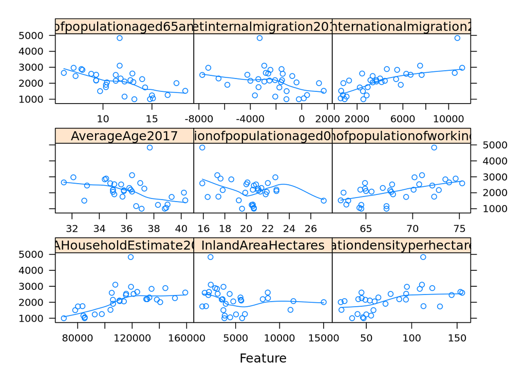

```r
caret::featurePlot(x = borough_summ[, c(4:12)],
            y = pull(borough_summ[, outcome]),
            plot = "scatter",
            type = c("p", "smooth"),
            layout = c(3, 3))
```

You can plot the predictors against each other to see if any are hugely overlapping.

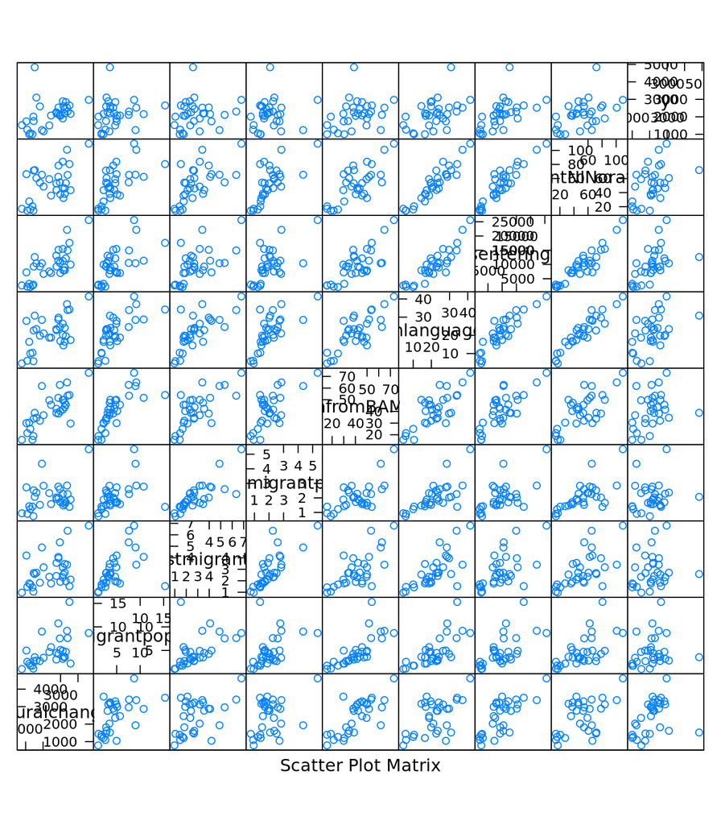

```r
caret::featurePlot(x = borough_summ[, c(13:20)],
            y = pull(borough_summ[, outcome]),
            plot = "pairs")
```

You can also compare density plots between groups of a categorical variable (in this case, whether a borough is deemed ‘Inner’ or ‘Outer’ London).

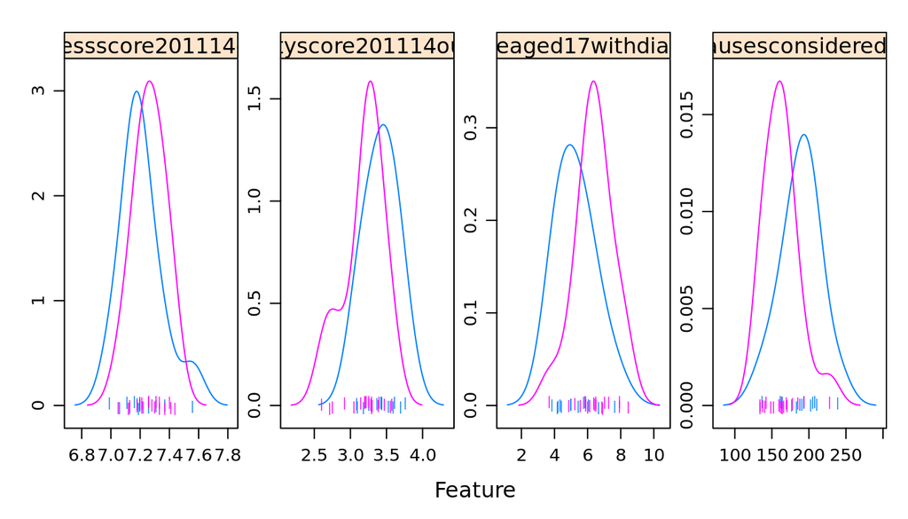

```r
caret::featurePlot(x = borough_summ[, 46:49],
            y = as.factor(borough_summ$InnerOuterLondon),
            plot = "density",
            scales = list(x = list(relation="free"),
                          y = list(relation="free")),
            adjust = 1.5,
            pch = "|",
            layout = c(4, 1))
```

## Creating Dummy variables

caret automatically identifies non-numeric variables (in our case, only InnerOuterLondon) and turns it into dummy variables (one-hot encoded), leaving the numeric variables untouched.

```r
dummies <- caret::dummyVars(as.formula(paste0(outcome, " ~ .")),
                     data = borough_summ)
borough_summ_d <- as.data.frame(predict(dummies, newdata = borough_summ)) %>%
  dplyr::select(-`InnerOuterLondonOuter London`) %>%
  dplyr::mutate(!!outcome := borough_summ$Total)
```

## Splitting data

In machine learning, it is standard to separate all the data into a training set and a test set (usually in some 80-20 or 70-30 split). The training set is used to train and tune the algorithms. The test set is not used for training at all, and is used as ‘new observations’ to see how the model will perform out in the real world.

However, there are some drawbacks to this method, and it is important to also verify performance using genuinely newly collected data, to check stability over time and also to ensure that biases contained in the original data collection are not embedded into the model.

```r
trainIndex <- caret::createDataPartition(borough_summ_d[, outcome],
                                         # 80-20% split
                                         p = .8,
                                         list = FALSE,
                                         times = 1)
training <- borough_summ_d[trainIndex, ]
test <- borough_summ_d[-trainIndex, ]
```

## Centering and Scaling

Preprocessing should be done on the basis of training data only.

We can impute missing values (using K-nearest neighbours), center our data (mean = 0), and scale it (standard deviation = 1).

```r
# No need to scale outcome variable
pre_proc <- caret::preProcess(training[, names(training) != outcome],
                              method = c("knnImpute", "center", "scale"))

train_t <- predict(pre_proc, training[, names(training) != outcome]) %>%
  dplyr::mutate(!!outcome := training[, outcome])
test_t <- predict(pre_proc, test[, names(test) != outcome]) %>%
  dplyr::mutate(!!outcome := test[, outcome])
(test_t)
```

| InnerOuterLondonInner London | GLAPopulationEstimate2017 | GLAHouseholdEstimate2017 | InlandAreaHectares | Populationdensityperhectare2017 | AverageAge2017 | Proportionofpopulationaged0152015 | Proportionofpopulationofworkingage2015 | Proportionofpopulationaged65andover2015 | Netinternalmigration2015 | Netinternationalmigration2015 | Netnaturalchange2015 | Xoflargestmigrantpopulation2011 | Xofsecondlargestmigrantpopulation2011 | Xofthirdlargestmigrantpopulation2011 | XofpopulationfromBAMEgroups2016 | Xpeopleaged3whosemainlanguageisnotEnglish2011Census | OverseasnationalsenteringtheUKNINo201516 | NewmigrantNINorates201516 | Employmentrate2015 | YouthUnemploymentclaimantrate1824Dec15 | ProportionoftheworkingagepopulationwhoclaimoutofworkbenefitsMay2016 | ModelledHouseholdmedianincomeestimates201213 | Numberofjobsbyworkplace2014 | Xofemploymentthatisinpublicsector2014 | JobsDensity2015 | Numberofactivebusinesses2015 | Twoyearbusinesssurvivalratesstartedin2013 | Firesperthousandpopulation2014 | MedianHousePrice2015 | … |
| --- | --- | --- | --- | --- | --- | --- | --- | --- | --- | --- | --- | --- | --- | --- | --- | --- | --- | --- | --- | --- | --- | --- | --- | --- | --- | --- | --- | --- | --- | --- |
| -0.9141741 | 2.03508656 | 2.2823596 | 1.1386657 | -0.8271688 | 0.37002539 | 0.7872734 | -0.83230640 | 0.4263119 | -0.1773099 | -0.57706416 | 0.7865186 | -0.34807539 | -0.1845340 | -0.6611933 | 0.6439386 | -0.7825944 | -0.3368798 | -0.8274070 | 0.59995305 | 1.13685164 | 0.05371143 | -0.3294645 | -0.18722072 | 0.5585233 | -0.4696031 | -0.09962598 | 0.4236470 | -0.1778952 | -0.7940652 | … |
| -0.9141741 | 1.41071477 | 1.0098335 | 0.2170153 | -0.3732894 | 0.02752255 | 0.5405160 | -0.36768205 | 0.0590278 | -2.0056803 | -0.07171028 | 1.0363959 | 0.87335985 | 2.5911173 | 0.1455027 | 0.8850640 | 1.3460481 | 0.9207206 | 0.5302028 | -0.03175239 | -0.54858859 | 0.11812186 | -0.4761686 | -0.04519491 | -0.9252792 | -0.3020192 | 0.24164025 | 0.5830841 | -0.7640503 | -0.1729919 | … |
| -0.9141741 | -1.74155770 | -2.0240117 | -0.3272682 | -0.7688411 | 0.41283825 | -0.1997559 | -0.26986640 | 0.4875259 | 0.9472229 | -0.54195672 | -1.2510227 | -0.79038040 | -0.7441193 | -0.7105683 | -0.6868092 | -0.5707613 | -1.1909527 | -1.0254425 | 0.36598807 | -1.40615691 | -1.70542780 | 0.7652952 | -0.62231568 | -0.1251761 | -0.1731086 | -0.80915735 | 0.9019582 | -0.9690647 | -0.2685417 | … |
| -0.9141741 | 0.06178546 | -0.2788803 | -0.2812208 | -0.1814540 | -0.44341886 | 0.7050209 | -0.09868901 | -0.4000773 | -1.6814140 | 0.51030021 | 0.7459136 | 0.04452244 | 0.2751377 | -0.4712958 | 0.6433762 | 0.5286230 | 1.0152974 | 1.3040587 | 0.06183360 | -0.09570584 | 0.20791174 | -0.9478303 | -0.61630400 | 1.2196033 | -0.6242959 | -0.58776628 | -0.9475116 | -0.2860448 | -0.4760327 | … |

```r
# Make column names R-friendly
colnames(train_t) <- gsub("\\.", "", make.names(colnames(train_t), unique=TRUE))
colnames(test_t) <- gsub("\\.", "", make.names(colnames(test_t), unique=TRUE))
```

You can even reduce feature space by applying Principal Component Analysis!

```r
pre_pca <- caret::preProcess(training[, names(training) != outcome],
                             method = c("pca"))

train_pca <- predict(pre_pca, training[, names(training) != outcome]) %>%
  dplyr::mutate(!!outcome := training[, outcome])
test_pca <- predict(pre_pca, test[, names(test) != outcome]) %>%
  dplyr::mutate(!!outcome := test[, outcome])

# Make column names R-friendly
colnames(train_pca) <- gsub("\\.", "", make.names(colnames(train_pca), unique=TRUE))
colnames(test_pca) <- gsub("\\.", "", make.names(colnames(test_pca), unique=TRUE))
```

# Model training and tuning

## Cross-validation

When training machine learning models, we must avoid overfitting to the data, especially when our dataset is so small. To do this, we can use cross-validation.

We divide our data into k groups or ‘folds’, and run the algorithm k times, using k-1 groups to train and the k’th group to validate the model. We finally calculate the average performance of the model across all the folds. This averaged performance score is what we compare between different model parameters to finally choose the best set of parameters.

Moreover, some models use a randomised starting position. caret allows you to repeat the algorithm a few times to make sure the results are stable over each repeat, and not due to some quirk of the randomisation.

```r
fitControl <- caret::trainControl(## 10-fold cross-validation
                           method = "repeatedcv",
                           number = 10,
                           ## repeated ten times
                           repeats = 10)
```

## Model training & tuning

Next, we must select the model we want to fit. You must do this on the basis of what you know about your data and problem, and not be afraid to test a few different ones to make sure you’re getting the most value. caret has a huge list of models available, which you can [find here](https://topepo.github.io/caret/available-models.html).

We will fit a boosted tree model contained within the [*mboost*](https://www.rdocumentation.org/packages/mboost/versions/2.9-1/topics/blackboost) package. This model trains successive shallow regression trees, such that the second tree is fitted to reduce the residuals of the first tree, etc. This model has two hyperparameters we can tune: mstop (number of boosting iterations) and maxdepth (maximum depth of each individual tree).

Depending on your problem, you may also want to decide if you’re interested in a different metric. You may choose to optimise for Root Mean Squared Error (RMSE, default), R Squared (Rsquared), or Mean Absolute Error (MAE).

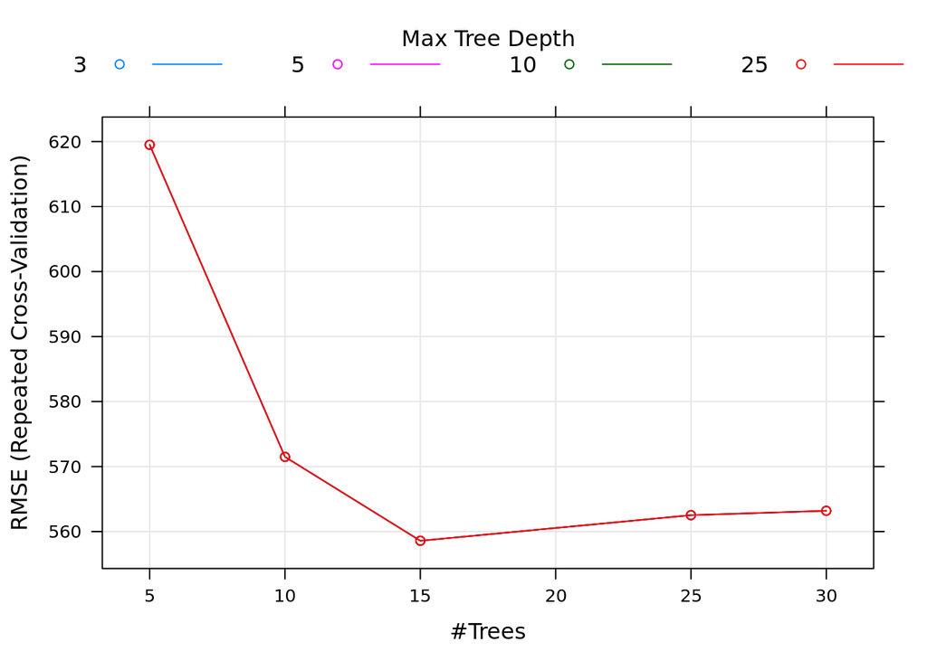

```r
blackboostGrid <- expand.grid(mstop = c(5, 10, 15, 25, 30),
                              maxdepth = c(3, 5, 10, 25))

blackboostFit <- caret::train(form = Total ~ .,
                       data = train_t,
                       method = "blackboost",
                       trControl = fitControl,
                       tuneGrid = blackboostGrid,
                       metric = "RMSE")
plot(blackboostFit)
```

```r
blackboostFit
```

```
## Boosted Tree
##
## 28 samples
## 48 predictors
##
## No pre-processing
## Resampling: Cross-Validated (10 fold, repeated 10 times)
## Summary of sample sizes: 25, 25, 25, 25, 26, 25, ...
## Resampling results across tuning parameters:
##
##   maxdepth  mstop  RMSE      Rsquared   MAE
##    3         5     619.5065  0.6731446  517.1475
##    3        10     571.4927  0.6843650  477.6958
##    3        15     558.5847  0.6879965  470.3428
##    3        25     562.5242  0.6830396  473.8741
##    3        30     563.1962  0.6830396  474.5625
##    5         5     619.5065  0.6731446  517.1475
##    5        10     571.4927  0.6843650  477.6958
##    5        15     558.5847  0.6879965  470.3428
##    5        25     562.5242  0.6830396  473.8741
##    5        30     563.1962  0.6830396  474.5625
##   10         5     619.5065  0.6731446  517.1475
##   10        10     571.4927  0.6843650  477.6958
##   10        15     558.5847  0.6879965  470.3428
##   10        25     562.5242  0.6830396  473.8741
##   10        30     563.1962  0.6830396  474.5625
##   25         5     619.5065  0.6731446  517.1475
##   25        10     571.4927  0.6843650  477.6958
##   25        15     558.5847  0.6879965  470.3428
##   25        25     562.5242  0.6830396  473.8741
##   25        30     563.1962  0.6830396  474.5625
##
## RMSE was used to select the optimal model using the smallest value.
## The final values used for the model were mstop = 15 and maxdepth = 3.
```

## Model interpretation

With an opaque model like boosted trees, it can be useful to find which variables end up being important to the final score. Different algorithms have different ways of calculating variable importance. caret allows you to access whichever method you like using the *varImp* function. This allows us to interpret why our boosted trees come to the results that they do.

```r
var_imp <- caret::varImp(blackboostFit)$importance
var_imp$variable <- rownames(var_imp)
(var_imp <- var_imp %>%
  dplyr::arrange(-Overall))
```

| Overall | variable |
| --- | --- |
| 100.000000 | Numberofjobsbyworkplace2014 |
| 93.921097 | Netinternationalmigration2015 |
| 92.642944 | Numberofactivebusinesses2015 |
| 89.526230 | Totalcarbonemissions2014 |
| 80.252774 | AveragePublicTransportAccessibilityscore2014 |
| 79.529883 | Firesperthousandpopulation2014 |
| 76.665609 | Twoyearbusinesssurvivalratesstartedin2013 |
| 73.853545 | AverageBandDCouncilTaxcharge201516 |
| 73.686221 | JobsDensity2015 |
| 70.698470 | GLAHouseholdEstimate2017 |

[output cut: 38 more lines]

## Model performance

Although the train object tells us the Root Mean Squared Error (RMSE), Rsquared and Mean Absolute Error (MAE), we may want to visually inspect the predictions to see if they behave as expected and if there are no hugely odd outliers.

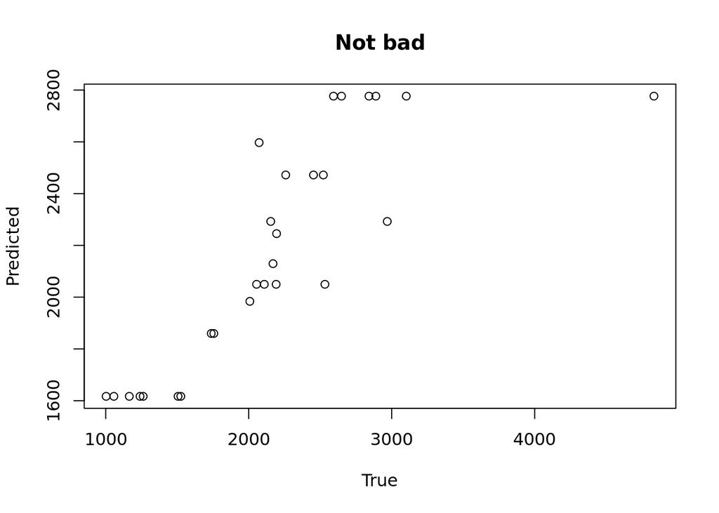

```r
plot(train_t[, outcome], predict(blackboostFit, newdata = train_t),
     main = "Not bad",
     xlab = "True",
     ylab = "Predicted")
```

This is also where we look at its performance in the test data we have held out until now, and check that the model doesn’t overfit terribly to the training data!

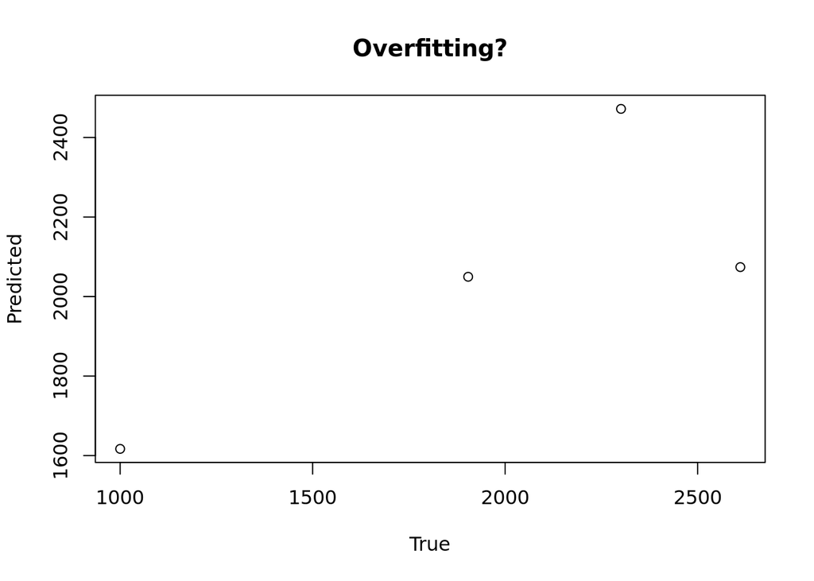

```r
plot(test_t[, outcome], predict(blackboostFit, newdata = test_t),
     main = "Overfitting?",
     xlab = "True",
     ylab = "Predicted")
```

# Comparing models

You will likely want to try out several models and pick the one that works best for your data. caret makes it really easy to compare their performances.

Let’s try training a generalised linear model, which has no hyperparameters to tune.

```r
glmFit <- caret::train(form = Total ~ .,
                       data = train_t,
                       method = "glm",
                       trControl = fitControl,
                       metric = "RMSE")
glmFit
```

```
## Generalized Linear Model
##
## 28 samples
## 48 predictors
##
## No pre-processing
## Resampling: Cross-Validated (10 fold, repeated 10 times)
## Summary of sample sizes: 25, 26, 25, 25, 25, 25, ...
## Resampling results:
##
##   RMSE      Rsquared   MAE
##   7164.077  0.7050234  5924.237
```

Then, we make a set of resampling results using both the models. The *summary* function then describes how the two models perform on the three performance metrics for regression.

```r
resamp <- caret::resamples(list(BlackBoost = blackboostFit,
                                GLM = glmFit))
summary(resamp)
```

```
##
## Call:
## summary.resamples(object = resamp)
##
## Models: BlackBoost, GLM
## Number of resamples: 100
##
## MAE
##                 Min.  1st Qu.    Median      Mean   3rd Qu.       Max.
## BlackBoost  77.26035 298.7615  416.0774  470.3428  620.4346   1223.366
## GLM        353.04797 660.1823 1149.8185 5924.2365 3322.1331 219158.845
##            NA's
## BlackBoost    0
## GLM           0
##
## RMSE
##                 Min.  1st Qu.   Median      Mean   3rd Qu.       Max. NA's
## BlackBoost  87.31697 354.9698  475.802  558.5847  667.1584   1668.717    0
## GLM        357.12354 708.4372 1245.862 7164.0766 4159.2669 269282.942    0
##
## Rsquared
##                    Min.   1st Qu.    Median      Mean   3rd Qu. Max. NA's
## BlackBoost 0.0000261978 0.4502565 0.8032495 0.6879965 0.9962735    1    0
## GLM        0.0002146095 0.4944172 0.8739449 0.7050234 0.9959348    1    0
```